# Gardnerella strain species and phylogeny

Hanna Berman

May 25, 2026

**Purpose:** Reconstruct *Gardnerella* spp. phylogeny with 22 genomes of *Gardnerella* strains and other genomes from phylogeny in Berman et al. (2024) (see references below)

The genomes not on the previous phylogeny were aligned to the reference *Gardnerella* genomes with Mash v2.3 to assess species assignment. Then, a phylogeny of all genomes in collection and 77 genomes from the previous Berman et al. (2024) phylogeny was plotted. The phylogeny was re-rooted at the outgroup with ape v5.8-1 and the outgroup tip removed. The bootstrap confidence values were added to the phylogeny with Phangorn v2.12.1, and the tree was visualized with ggtree v4.0.4.

```r
library(tidyverse)
library(formattable)
library(ape)
library(phangorn)
library(ggtree)
library(kableExtra)
`%!in%` <- negate(`%in%`)
```

```r
figure_out <- "../../experiments_figures"

species <- c("Gardnerella vaginalis", "Gardnerella lacydonensis", "Gardnerella pickettii", "Gardnerella piotii", "Gardnerella leopoldii", "Gardnerella swidsinskii", "Gardnerella sp. 7", "Gardnerella greenwoodii", "Gardnerella bretellae", "Gardnerella sp. 10", "Gardnerella sp. 11", "Gardnerella sp. 12", "Gardnerella sp. 13", "Gardnerella massiliensis")

species_names <- tribble(~species_name, ~refGenomospecies, ~name_reference,
      "Gardnerella vaginalis", "GS1", "Vaneechoutte 2019",
      "Gardnerella lacydonensis", "GS2", "Allini Ntiguemassa 2026",
      "Gardnerella pickettii", "GS3", "Sousa 2023",
      "Gardnerella piotii", "GS4", "Vaneechoutte 2019",
      "Gardnerella leopoldii", "GS5", "Vaneechoutte 2019",
      "Gardnerella swidsinskii", "GS6", "Vaneechoutte 2019",
      "Gardnerella sp. 7", "GS7", NA,
      "Gardnerella greenwoodii", "GS8", "Sousa 2023",
      "Gardnerella bretellae", "GS9", "Allini Ntiguemassa 2026",
      "Gardnerella sp. 10", "GS10", NA,
      "Gardnerella sp. 11", "GS11", NA,
      "Gardnerella sp. 12", "GS12", NA,
      "Gardnerella sp. 13", "GS13", NA,
      "Gardnerella massiliensis", "GS14", "Allini Ntiguemassa 2026")
```

```r
# Set paths

#Newly sequenced strain data (genomes not on Berman et al., 2024 mSystems paper phylogeny)
metadata_path <- "./strainIDs.csv" # strain metadata
new_genomes_path <- "../../strain_genomes/prokka_annotated_genomes" # path to strain assemblies

#Metadata and sequences from Berman et al., 2024 mSystems paper for comparisons
ref_metadata_path <- "./2024mSystems_GardnerellaMetadata.csv" # reference Gardnerella dataframe
ref_clades_species_path <- "./2024mSystems_refGardnerellaCladesGenomos.csv" # clade and species identity of reference Gardnerella strains
ref_genomes_path <- "../../../gardPhylogeny/prokka_annotated_genomes/fna" #reference Gardnerella genomes

# Strain phylogeny
outgroup_tree_path <- "./ml_phylogeny_output/RAxML_labelledTree.rootedGardTree"
bootstraps_path <- "./ml_phylogeny_output/RAxML_bootstrap.FCBootstrap"
```

# Genomes

## Isolates

Isolate genome files and metadata from isolate genomes not on Berman et al. (2024) phylogeny (new genomes)

```r
strainIDs <- read_csv(metadata_path)

new_genomes <- file.path(new_genomes_path, "fna") |> #list of newly sequenced strain assemblies
  list.files(full.names = TRUE)
```

## Reference genomes

Read in genomes and metadata from isolate genomes on previous phylogeny (reference genomes)

```r
# reference Gardnerella metadata dataframe
gard_ref_metadata <- read_csv(ref_metadata_path) |>
  select(Strain, GenBank_accession) |>
  dplyr::rename(refStrain=Strain)

# list of reference genomes
ref_genomes <- list.files(ref_genomes_path, full.names = TRUE)

# clade and species names
ref_clades_species <- read_csv(ref_clades_species_path) |>
  dplyr::rename(refStrain=Strain,
                refClade=Clade,
                refGenomospecies=Genomospecies)
```

## Genome tables

Table S1: Isolate species, sources, and sequences

```r
strain_table <- strainIDs %>%
  select(strain, species_name, ncsu_sequence, genbank_accession, source) %>%
  replace_na(list(ncsu_sequence="",
                  genbank_accession="")) %>%
  mutate(species_name=factor(species_name, species)) %>%
  arrange(species_name) %>%
  dplyr::rename(`Strain ID`=strain,
                `Species Name`=species_name,
                `Sequenced as Part of this Study`=ncsu_sequence,
                `GenBank Accession`=genbank_accession,
                Source=source) %>%
  kbl(align=c("llcl"), caption ="Table S1. Strain Species and Genomes") %>%
  kable_classic(full_width=TRUE, html_font = "Arial")


strain_table
```

Table S1. Strain Species and Genomes

Strain ID

Species Name

Sequenced as Part of this Study

GenBank Accession

Source

C0011E4

Gardnerella vaginalis

Ravel Lab, University of Maryland

14018

Gardnerella vaginalis

GCA_000178355.1

Jefferson Lab, Virginia Commonwealth University

315-A

Gardnerella vaginalis

GCA_000214315.2

BEI Resources #HM-133

C0084H9

Gardnerella lacydonensis

Ravel Lab, Univerisity of Maryland

JCP7275

Gardnerella lacydonensis

GCA_000414705.1

BEI Resources #HM-1105

JCP8108

Gardnerella lacydonensis

GCA_000414525.1

BEI Resources #HM-1114

C0040C2

Gardnerella pickettii

Ravel Lab, Univerisity of Maryland

JCP8017B

Gardnerella pickettii

GCA_000414585.1

BEI Resources #HM-1111

C0093B3

Gardnerella piotii

Ravel Lab, Univerisity of Maryland

UM35

Gardnerella piotii

Jefferson Lab, Virginia Commonwealth University

JCP8066

Gardnerella piotii

GCA_000414565.1

BEI Resources #HM-1112

C0096A1

Gardnerella leopoldii

Ravel Lab, Univerisity of Maryland

AMD

Gardnerella leopoldii

GCA_000176475.1

Jefferson Lab, Virginia Commonwealth University

C0102A2

Gardnerella swidsinskii

Ravel Lab, Univerisity of Maryland

Gv5-1

Gardnerella swidsinskii

GCA_000176495.1

Jefferson Lab, Virginia Commonwealth University

UM224

Gardnerella swidsinskii

Jefferson Lab, Virginia Commonwealth University

C0179B4

Gardnerella sp. 7

Ravel Lab, Univerisity of Maryland

C0056B5

Gardnerella greenwoodii

Ravel Lab, Univerisity of Maryland

Gv101

Gardnerella greenwoodii

GCA_000165615.2

Jefferson Lab, Virginia Commonwealth University

C0100B2

Gardnerella sp. 10

Ravel Lab, Univerisity of Maryland

C0101A1

Gardnerella sp. 11

Ravel Lab, Univerisity of Maryland

CMW7778B

Gardnerella sp. 12

GCA_001563665.1

BEI Resources #HM-1298

```r
#strain_table %>%
#  save_kable(file = file.path(figure_out, paste(Sys.Date(), "TableS1_StrainSpeciesGenomes.png")), zoom=5)
```

Table S2: Strain species and GenBank accessions for all genomes on phylogeny that are not strains tested in this study

```r
ref_table <- ref_clades_species %>%
  filter(refStrain %!in% c(strainIDs$strain, "101", "5-1")) %>%
  left_join(gard_ref_metadata) %>%
  left_join(species_names) %>%
  select(refStrain, species_name, GenBank_accession) %>%
  mutate(species_name=factor(species_name, levels=species)) %>%
  arrange(species_name) %>%
  dplyr::rename(Strain=refStrain,
                `Species Name`=species_name,
                `GenBank Accession`=GenBank_accession) %>%
  kbl(caption="Table S2. Refence Gardnerella Genomes") %>%
  kable_classic(full_width=TRUE, html_font = "Arial")

ref_table
```

Table S2. Refence Gardnerella Genomes

| Strain | Species Name | GenBank Accession |
| --- | --- | --- |
| ATCC_14019 | Gardnerella vaginalis | GCA_000159155.2 |
| HMP9231 | Gardnerella vaginalis | GCA_000213955.1 |
| 284V | Gardnerella vaginalis | GCA_000263435.1 |
| 75712 | Gardnerella vaginalis | GCA_000263535.1 |
| 0288E | Gardnerella vaginalis | GCA_000263555.1 |
| JCP7672 | Gardnerella vaginalis | GCA_000414645.1 |
| JCP7276 | Gardnerella vaginalis | GCA_000414685.1 |
| 3549624 | Gardnerella vaginalis | GCA_001049785.1 |
| UMB0061 | Gardnerella vaginalis | GCA_002861165.1 |
| UMB0775 | Gardnerella vaginalis | GCA_002861925.1 |
| UMB0770 | Gardnerella vaginalis | GCA_002861945.1 |
| UMB0386 | Gardnerella vaginalis | GCA_002861965.1 |
| UMB0032B | Gardnerella vaginalis | GCA_002862005.1 |
| UMB0233 | Gardnerella vaginalis | GCA_002862045.1 |
| UMB0768 | Gardnerella vaginalis | GCA_002884835.1 |
| DNF01149 | Gardnerella vaginalis | GCA_002894105.1 |
| UGent_25.49 | Gardnerella vaginalis | GCA_003397605.1 |
| UGent_09.07 | Gardnerella vaginalis | GCA_003397665.1 |
| GH015 | Gardnerella vaginalis | GCA_003408745.1 |
| N165 | Gardnerella vaginalis | GCA_003408785.1 |
| NR038 | Gardnerella vaginalis | GCA_003585655.1 |
| NR039 | Gardnerella vaginalis | GCA_003585755.1 |
| FDAARGOS_568 | Gardnerella vaginalis | GCA_003812765.1 |
| UMB0143 | Gardnerella vaginalis | GCA_013315005.1 |
| UMB0736 | Gardnerella vaginalis | GCA_013315025.1 |
| UMB0202 | Gardnerella vaginalis | GCA_013315075.1 |
| 41V | Gardnerella lacydonensis | GCA_000165635.2 |
| 55152 | Gardnerella lacydonensis | GCA_000263475.1 |
| 1400E | Gardnerella lacydonensis | GCA_000263495.1 |
| 00703C2mash | Gardnerella pickettii | GCA_000263515.1 |
| 00703Bmash | Gardnerella pickettii | GCA_000263615.1 |
| JCP8017A | Gardnerella pickettii | GCA_000414605.1 |
| JCP7719 | Gardnerella pickettii | GCA_000414625.1 |
| JCP7659 | Gardnerella pickettii | GCA_000414665.1 |
| GED7275B | Gardnerella pickettii | GCA_001546445.1 |
| UMB0833 | Gardnerella pickettii | GCA_002861885.1 |
| UMB0830 | Gardnerella pickettii | GCA_002861905.1 |
| W11 | Gardnerella pickettii | GCA_003369875.1 |
| N101 | Gardnerella pickettii | GCA_003369895.1 |
| N95 | Gardnerella pickettii | GCA_003369965.1 |
| N144 | Gardnerella pickettii | GCA_003408835.1 |
| UMB0558 | Gardnerella pickettii | GCA_013315115.1 |
| JCP8522 | Gardnerella piotii | GCA_000414425.1 |
| JCP8151B | Gardnerella piotii | GCA_000414485.1 |
| JCP8151A | Gardnerella piotii | GCA_000414505.1 |
| JCP8070 | Gardnerella piotii | GCA_000414545.1 |
| UGent_18.01 | Gardnerella piotii | GCA_003397585.1 |
| UGent_21.28 | Gardnerella piotii | GCA_003397615.1 |
| 6420B | Gardnerella leopoldii | GCA_000263575.1 |
| UMB0913 | Gardnerella leopoldii | GCA_002861145.1 |
| UMB0682 | Gardnerella leopoldii | GCA_002862065.1 |
| UGent_06.41 | Gardnerella leopoldii | GCA_003293675.1 |
| UGent_09.48 | Gardnerella leopoldii | GCA_003397635.1 |
| UMB0742 | Gardnerella leopoldii | GCA_013315135.1 |
| UMB1489 | Gardnerella leopoldii | GCA_013315195.1 |
| UMB0662 | Gardnerella leopoldii | GCA_013315255.1 |
| 409-05 | Gardnerella swidsinskii | GCA_000025205.1 |
| GV37 | Gardnerella swidsinskii | GCA_001953155.1 |
| UMB1642 | Gardnerella swidsinskii | GCA_002884795.1 |
| UMB0264 | Gardnerella swidsinskii | GCA_002884875.1 |
| DNF01162 | Gardnerella swidsinskii | GCA_002894125.1 |
| GS_9838-1 | Gardnerella swidsinskii | GCA_003397705.1 |
| GS_10234 | Gardnerella swidsinskii | GCA_003397745.1 |
| N72 | Gardnerella swidsinskii | GCA_003408815.1 |
| UMB1698 | Gardnerella swidsinskii | GCA_013315145.1 |
| UMB0769 | Gardnerella swidsinskii | GCA_013315215.1 |
| JCP8481A | Gardnerella sp. 7 | GCA_000414465.1 |
| PSS_7772B | Gardnerella sp. 7 | GCA_001546485.1 |
| 00703Dmash | Gardnerella greenwoodii | GCA_000263635.1 |
| UMB1686 | Gardnerella greenwoodii | GCA_002884775.1 |
| 6119V5 | Gardnerella bretellae | GCA_000263655.1 |
| N160 | Gardnerella bretellae | GCA_003408775.1 |
| 1500E | Gardnerella sp. 10 | GCA_000263595.1 |
| GED7760B | Gardnerella sp. 11 | GCA_001546455.1 |
| KA00735 | Gardnerella sp. 12 | GCA_002894085.1 |
| KA00225 | Gardnerella sp. 13 | GCA_002896555.1 |
| NR010 | Gardnerella massiliensis | GCA_003408845.1 |

```r
#ref_table %>%
#  save_kable(file = file.path(figure_out, paste(Sys.Date(), "TableS2_refStrainGenomes.png")), zoom=5)
```

# Annotation Stats

Genome sizes and gene counts from Prokka outputs for new genomes

```r
anno_stats0 <- file.path(new_genomes_path, "txt") %>%
  list.files(full.names = TRUE) %>%
  map(read_tsv) %>%
  map(~separate(.x, 1, c("cat", "count"), ": "))

names(anno_stats0) <- list.files(file.path(new_genomes_path, "txt"))

anno_stats <- anno_stats0 %>%
  map2(., names(.), ~mutate(.x, Strain=.y)) %>%
  map(~spread(.x, cat, count)) %>%
  purrr::reduce(full_join) %>%
  mutate(Strain=str_extract(Strain, ".*(?=\\.txt)"))
```

# Species of strains not on previous phylogeny

Compute approximate average nucleotide identity with Mash v2.3

```r
# compute alignments and keep match of smallest distance (closest reference genome)
getGenomospecies <- function(inputGenome){
  genomospecies <- ref_genomes %>%
    map(~system(paste("mash dist", inputGenome,  .x), intern = TRUE)) %>%
    map(as.data.frame) %>%
    map(~separate(.x, 1, c("strain", "refStrain", "distance", "p", "matching_hashes"), sep="\t")) %>%
    map(~mutate(.x, strain=str_extract(strain, "(?<=fna/).*(?=\\.fna)"))) %>%
    map(~mutate(.x, refStrain=str_extract(refStrain, "(?<=fna/).*(?=\\.fna)"))) %>%
    purrr::reduce(full_join) %>%
    mutate_at(vars("distance", "p"), as.numeric) %>%
    left_join(strainIDs[,c("strain","genomospecies", "species_name")], by="strain") %>%
    left_join(ref_clades_species[,c("refStrain", "refGenomospecies")], by="refStrain") %>%
    filter(distance==min(distance)) %>%
    mutate(ANI=round((1-distance)*100, 2)) %>%
  return(genomospecies)
}

# add assigned genomospecies of strain and reference genomes
species_table <- new_genomes %>%
  map(getGenomospecies) %>%
  purrr::reduce(full_join)

# print table
species_table %>%
  dplyr::rename("Reference Strain"=refStrain,
                "Strain Genomospecies"=genomospecies,
                "Species Name"=species_name,
                "Reference Genomospecies"=refGenomospecies,
                "ANI (%)"=ANI) %>%
  select(strain, `Reference Strain`, `Species Name`, `Strain Genomospecies`, `Reference Genomospecies`, `ANI (%)`) %>%
  formattable()
```

| strain | Reference Strain | Species Name | Strain Genomospecies | Reference Genomospecies | ANI (%) |
| --- | --- | --- | --- | --- | --- |
| 14018 | ATCC_14019 | Gardnerella vaginalis | GS1 | GS1 | 99.99 |
| C0011E4 | UMB0233 | Gardnerella vaginalis | GS1 | GS1 | 99.01 |
| C0040C2 | UMB0558 | Gardnerella pickettii | GS3 | GS3 | 99.46 |
| C0056B5 | UMB1686 | Gardnerella greenwoodii | GS8 | GS8 | 97.77 |
| C0084H9 | JCP7275 | Gardnerella lacydonensis | GS2 | GS2 | 97.68 |
| C0093B3 | JCP8151B | Gardnerella piotii | GS4 | GS4 | 97.95 |
| C0096A1 | UMB0742 | Gardnerella leopoldii | GS5 | GS5 | 99.12 |
| C0096A1 | UMB0913 | Gardnerella leopoldii | GS5 | GS5 | 99.12 |
| C0100B2 | 6119V5 | Gardnerella sp. 10 | GS10 | GS9 | 98.28 |
| C0101A1 | GED7760B | Gardnerella sp. 11 | GS11 | GS11 | 98.53 |
| C0102A2 | DNF01162 | Gardnerella swidsinskii | GS6 | GS6 | 99.78 |
| C0179B4 | PSS_7772B | Gardnerella sp. 7 | GS7 | GS7 | 98.90 |
| JCP8017B | JCP8017A | Gardnerella pickettii | GS3 | GS3 | 99.97 |
| UM224 | 409-05 | Gardnerella swidsinskii | GS6 | GS6 | 98.95 |
| UM35 | UGent_21.28 | Gardnerella piotii | GS4 | GS4 | 98.14 |

C0100B2 was provided by Ravel Lab as *Gardnerella* sp. 10, but best match is *Gardnerella* sp. 9. Check additional matches.

```r
C0100B2_path <- file.path(new_genomes_path, "fna", "C0100B2.fna")

ref_genomes %>%
    map(~system(paste("mash dist", C0100B2_path,  .x), intern = TRUE)) %>%
    map(as.data.frame) %>%
    map(~separate(.x, 1, c("strain", "refStrain", "distance", "p", "matching_hashes"), sep="\t")) %>%
    map(~mutate(.x, strain=str_extract(strain, "(?<=fna/).*(?=\\.fna)"))) %>%
    map(~mutate(.x, refStrain=str_extract(refStrain, "(?<=fna/).*(?=\\.fna)"))) %>%
    purrr::reduce(full_join) %>%
    mutate_at(vars("distance", "p"), as.numeric) %>%
    left_join(strainIDs[,c("strain","genomospecies", "species_name")], by="strain") %>%
    left_join(ref_clades_species[,c("refStrain", "refGenomospecies")], by="refStrain") %>%
    mutate(ANI=round((1-distance)*100, 2)) %>%
    filter(ANI>90) %>%
    formattable() %>%
    arrange(-ANI) %>%
    dplyr::rename("Reference Strain"=refStrain,
                "Strain Genomospecies"=genomospecies,
                "Species Name"=species_name,
                "Reference Genomospecies"=refGenomospecies,
                "ANI (%)"=ANI) %>%
  select(strain, `Reference Strain`, `Species Name`, `Strain Genomospecies`, `Reference Genomospecies`, `ANI (%)`) %>%
  formattable()
```

| strain | Reference Strain | Species Name | Strain Genomospecies | Reference Genomospecies | ANI (%) |
| --- | --- | --- | --- | --- | --- |
| C0100B2 | 6119V5 | Gardnerella sp. 10 | GS10 | GS9 | 98.28 |
| C0100B2 | N160 | Gardnerella sp. 10 | GS10 | GS9 | 97.99 |
| C0100B2 | 1500E | Gardnerella sp. 10 | GS10 | GS10 | 96.62 |
| C0100B2 | UMB1686 | Gardnerella sp. 10 | GS10 | GS8 | 96.45 |
| C0100B2 | 101 | Gardnerella sp. 10 | GS10 | GS8 | 96.16 |
| C0100B2 | 00703Dmash | Gardnerella sp. 10 | GS10 | GS8 | 96.10 |
| C0100B2 | 409-05 | Gardnerella sp. 10 | GS10 | GS6 | 90.74 |
| C0100B2 | UMB0769 | Gardnerella sp. 10 | GS10 | GS6 | 90.56 |
| C0100B2 | N72 | Gardnerella sp. 10 | GS10 | GS6 | 90.44 |
| C0100B2 | JCP8481A | Gardnerella sp. 10 | GS10 | GS7 | 90.38 |
| C0100B2 | PSS_7772B | Gardnerella sp. 10 | GS10 | GS7 | 90.32 |
| C0100B2 | GV37 | Gardnerella sp. 10 | GS10 | GS6 | 90.19 |
| C0100B2 | UMB1698 | Gardnerella sp. 10 | GS10 | GS6 | 90.12 |
| C0100B2 | 5-1 | Gardnerella sp. 10 | GS10 | GS6 | 90.05 |
| C0100B2 | UMB0913 | Gardnerella sp. 10 | GS10 | GS5 | 90.05 |
| C0100B2 | UMB1642 | Gardnerella sp. 10 | GS10 | GS6 | 90.05 |

Average nucleotide identity with *Gardnerella* sp. 10 strain 1500E is greater than 96%, the cutoff for species identity determined by Ciufo et al. (2018).

# Figure 1: Phylogeny

## Tree before rooting

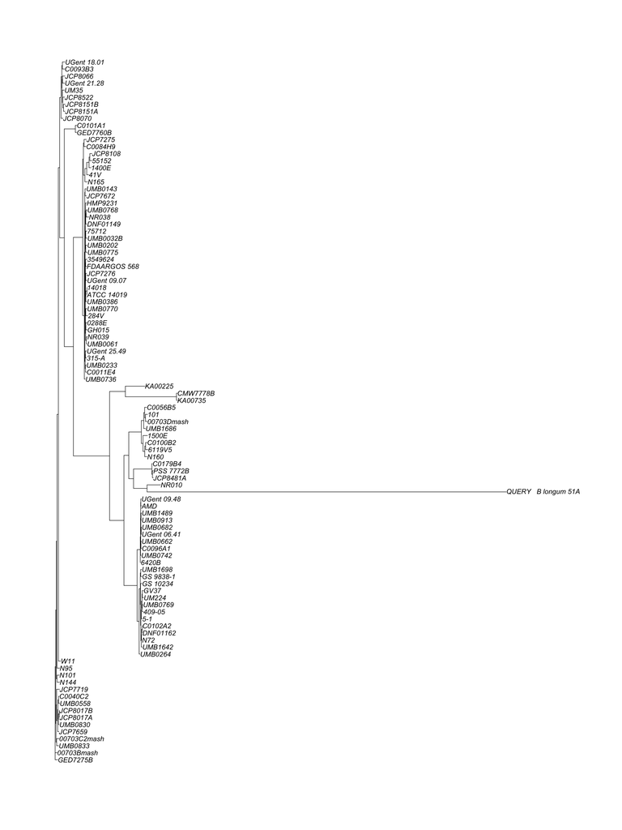

```r
outgroup_tree <- ape::read.tree(outgroup_tree_path)
plot(outgroup_tree)
```

## Root tree

Re-root the tree at the outgroup.

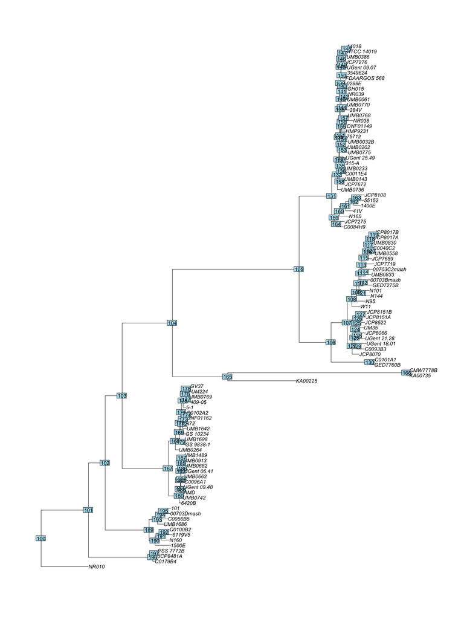

```r
rooted_tree <- ape::root(outgroup_tree, outgroup = "QUERY___B_longum_51A", resolve.root = TRUE) |> # re-root at outgroup
  drop.tip(tip="QUERY___B_longum_51A") |> # remove outgroup tip
  ladderize(right = FALSE)
plot(rooted_tree)
nodelabels() # show nodelabel numbers
```

```r
#write.tree(rooted_tree, "./rootedGardPhylogeny_noOutgroup.tre") # save outgroup rooted tree
```

## Add bootstraps

Add bipartition bootstrap confidence information to nodes.

```r
bootstraps <- ape::read.tree(bootstraps_path) # read bipartition bootstrap trees

bs_rooted_tree <- phangorn::plotBS(rooted_tree, bootstraps, type="none", method="FBP", digits = 3) # Add bipartition bootstrap values to nodes
bs_rooted_tree$node.label <- bs_rooted_tree$node.label*100
```

## Plot

Add tree metadata to show which strains are in our collection for this study.

```r
tree_metadata <- tibble(strain=bs_rooted_tree$tip.label) |>
  mutate(in_collection=strain %in% strainIDs$strain)
```

## Figure 1: Gardnerella strain phylogeny

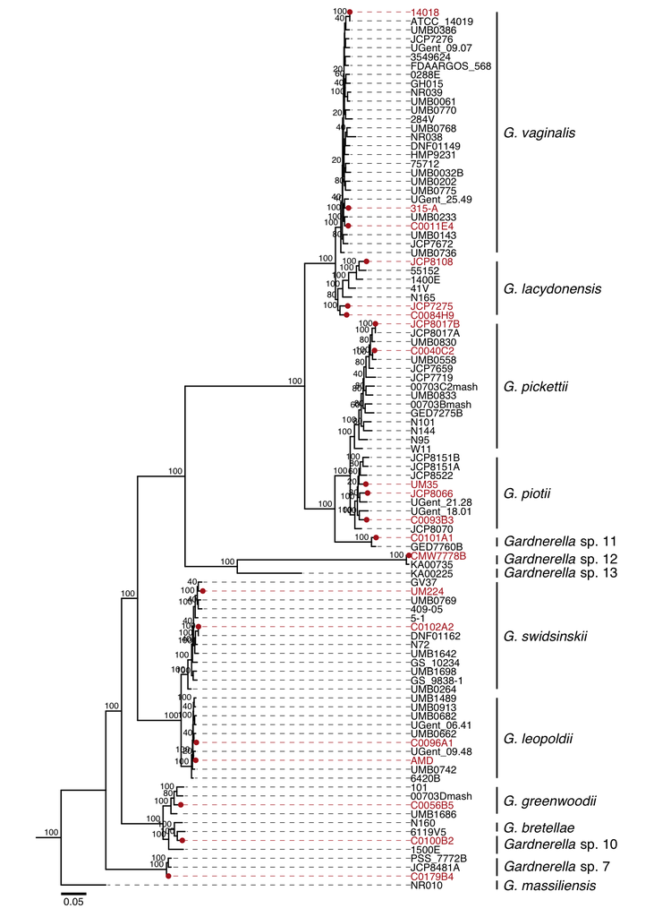

```r
ggtree(bs_rooted_tree) %>%
     flip(192, 192) %>%
     rotate(191) %<+% tree_metadata +
     geom_rootedge(rootedge = 0.05, colour = "black", linewidth = 0.5) +
     geom_tiplab(aes(color=in_collection), align = TRUE, linetype = "dashed", linesize = 0.2, show.legend=FALSE, size=3) +
  scale_color_manual(values = c("black", "#B22222")) +
  geom_tippoint(aes(alpha=in_collection), color="#B22222", show.legend = FALSE) +
  scale_alpha_manual(values=c(0,1)) +
  geom_nodelab(hjust=1.3, vjust=-0.4, size = 2.5) +
  ggtree::geom_treescale(linesize = 1, x=0, y=0, fontsize = 3, offset = -1.25, width = 0.05) +
  ggplot2::xlim(-0.05, 1.1) +
  geom_striplab("14018", "UMB0736", label="G. vaginalis",  offset = 0.16, offset.text = 0.005, barsize = 0.6, fontsize = 4, fontface=3) + #GS1
  geom_striplab("JCP8108", "C0084H9", label="G. lacydonensis", offset = 0.16, offset.text = 0.005, barsize = 0.6, fontsize = 4, fontface=3) + #GS2
  geom_striplab("JCP8017B", "W11", label="G. pickettii", offset = 0.16, offset.text = 0.005, barsize = 0.6, fontsize = 4, fontface=3) + #GS3
  geom_striplab("JCP8151B", "JCP8070", label="G. piotii", offset = 0.16, offset.text = 0.005, barsize = 0.6, fontsize = 4, fontface=3) + #GS4
  geom_strip("C0101A1", "GED7760B", label="paste(italic(' Gardnerella'),' sp. 11')", offset = 0.16, offset.text = 0.005, barsize = 0.6, fontsize = 4, parse=TRUE) + #GS11
  geom_strip("CMW7778B", "KA00735", label="paste(italic(' Gardnerella'),' sp. 12')", offset = 0.16, offset.text = 0.005, barsize = 0.6, fontsize = 4, parse = TRUE) + #GS12
  geom_strip("KA00225", "KA00225", label="paste(italic(' Gardnerella'),' sp. 13')", offset = 0.16, offset.text = 0.005, barsize = 0.6, fontsize = 4, parse = TRUE, extend=0.5) + #GS13
  geom_striplab("GV37", "UMB0264", label="G. swidsinskii", offset = 0.16, offset.text = 0.005, barsize = 0.6, fontsize = 4, fontface=3) + #GS6
  geom_striplab("UMB1489", "6420B", label="G. leopoldii", offset = 0.16, offset.text = 0.005, barsize = 0.6, fontsize = 4, fontface=3) + #GS5
  geom_striplab("101", "UMB1686", label="G. greenwoodii", offset = 0.16, offset.text = 0.005, barsize = 0.6, fontsize = 4, fontface=3) + #GS8
  geom_striplab("N160", "6119V5", label="G. bretellae", offset = 0.16, offset.text = 0.005, barsize = 0.6, fontsize = 4, fontface=3) + #GS9
  geom_strip("C0100B2", "1500E", label="paste(italic(' Gardnerella'),' sp. 10')", offset = 0.16, offset.text = 0.005, barsize = 0.6, fontsize = 4, parse=TRUE, extend=0.5) + #GS10
  geom_strip("PSS_7772B", "C0179B4", label="paste(italic(' Gardnerella'),' sp. 7')", offset = 0.16, offset.text = 0.005, barsize = 0.6, fontsize = 4, parse=TRUE) + #GS7
  geom_striplab("NR010", "NR010", label="G. massiliensis", offset = 0.16, offset.text = 0.005, barsize = 0.6, fontsize = 4, fontface=3, extend=0.5) #GS14
```

```r
#ggsave(filename = file.path(figure_out, paste(Sys.Date(), "Figure1_strain_phylogeny.png", sep="_")))
```

# References

Andrews S (2010) FastQC: A Quality Control Tool for High Throughput Sequence Data. Available at: https://www.bioinformatics.babraham.ac.uk/projects/fastqc/. https://www.bioinformatics.babraham.ac.uk/projects/fastqc/

Bankevich A, Nurk S, Antipov D, et al. (2012) SPAdes: a new genome assembly algorithm and its applications to single-cell sequencing. *Journal of Computational Biology* 19(5): 455–477. https://doi.org/10.1089/cmb.2012.0021

Berman HL, Goltsman DSA, Anderson M, et al. (2024) Gardnerella diversity and ecology in pregnancy and preterm birth. mSystems 9(6). *American Society for Microbiology*: e0133923. https://doi.org/10.1128/msystems.01339-23

Ciufo S, Kannan S, Sharma S, et al. (2018) Using average nucleotide identity to improve taxonomic assignments in prokaryotic genomes at the NCBI. *International Journal of Systematic and Evolutionary Microbiology* 68(7): 2386–2392. https://doi.org/10.1099/ijsem.0.002809 Ondov BD, Treangen TJ, Melsted P, et al. (2016) Mash: fast genome and metagenome distance estimation using MinHash. Genome biology 17(1): 132. http://doi.org/10.1186/s13059-016-0997-x

Paradis E and Schliep K (2019) ape 5.0: an environment for modern phylogenetics and evolutionary analyses in R. *Bioinformatics* 35(3): 526–528. https://doi.org/10.1093/bioinformatics/bty633

Schliep KP (2011) phangorn: phylogenetic analysis in R. *Bioinformatics* 27(4): 592–593. https://doi.org10.1093/bioinformatics/btq706

Seemann T (2014) Prokka: rapid prokaryotic genome annotation. *Bioinformatics* 30(14): 2068–2069. https://doi.org/10.1093/bioinformatics/btu153

Stamatakis A (2014) RAxML version 8: a tool for phylogenetic analysis and post-analysis of large phylogenies. *Bioinformatics* 30(9): 1312–1313. https://doi.org/10.1093/bioinformatics/btu033

Yu G, Smith DK, Zhu H, et al. (2017) Ggtree: An r package for visualization and annotation of phylogenetic trees with their covariates and other associated data. *Methods in Ecology and Evolution* 8(1): 28–36. https://doi.org/10.1111/2041-210x.12628